# Tunning XGBoost

data from [here]https://www.kaggle.com/c/GiveMeSomeCredit/data

tips for the parameters[here]https://www.analyticsvidhya.com/blog/2016/03/complete-guide-parameter-tuning-xgboost-with-codes-python/

and more infromation here http://xgboost.readthedocs.io/en/latest/

## Xgboost Parameters

Here some tips about this model parameters:

- **eta** [default=0.3] Analogous to learning rate in GBM. Makes the model more robust by shrinking the weights on each step Typical final values to be used: 0.01-0.2
- **min_child_weight** [default=1] Defines the minimum sum of weights of all observations required in a child. This is similar to min_child_leaf in GBM but not exactly. This refers to min “sum of weights” of observations while GBM has min “number of observations”. Used to control over-fitting. Higher values prevent a model from learning relations which might be highly specific to the particular sample selected for a tree. Too high values can lead to under-fitting hence, it should be tuned using CV.
- **max_depth [default=6]** The maximum depth of a tree, same as GBM. Used to control over-fitting as higher depth will allow model to learn relations very specific to a particular sample. Should be tuned using CV. Typical values: 3-10
- **max_leaf_nodes** The maximum number of terminal nodes or leaves in a tree. Can be defined in place of max_depth. Since binary trees are created, a depth of ‘n’ would produce a maximum of 2^n leaves. If this is defined, GBM will ignore max_depth.
- **gamma [default=0]** A node is split only when the resulting split gives a positive reduction in the loss function. Gamma specifies the minimum loss reduction required to make a split. Makes the algorithm conservative. The values can vary depending on the loss function and should be tuned. max_delta_step [default=0] In maximum delta step we allow each tree’s weight estimation to be. If the value is set to 0, it means there is no constraint. If it is set to a positive value, it can help making the update step more conservative. Usually this parameter is not needed, but it might help in logistic regression when class is extremely imbalanced. This is generally not used but you can explore further if you wish.
- **subsample [default=1]** Same as the subsample of GBM. Denotes the fraction of observations to be randomly samples for each tree. Lower values make the algorithm more conservative and prevents overfitting but too small values might lead to under-fitting. Typical values: 0.5-1
- **colsample_bytree [default=1]** Similar to max_features in GBM. Denotes the fraction of columns to be randomly samples for each tree. Typical values: 0.5-1
- **colsample_bylevel [default=1]** Denotes the subsample ratio of columns for each split, in each level. I don’t use this often because subsample and colsample_bytree will do the job for you. but you can explore further if you feel so.
- **lambda [default=1]** L2 regularization term on weights (analogous to Ridge regression) This used to handle the regularization part of XGBoost. Though many data scientists don’t use it often, it should be explored to reduce overfitting.
- **alpha [default=0]** L1 regularization term on weight (analogous to Lasso regression) Can be used in case of very high dimensionality so that the algorithm runs faster when implemented scale_pos_weight [default=1] A value greater than 0 should be used in case of high class imbalance as it helps in faster convergence.

## Objective - metric Optimization

These parameters are used to define the optimization objective the metric to be calculated at each step.

- **objective [default=reg:linear]** This defines the loss function to be minimized. Mostly used values are:
  - **binary:logistic** –logistic regression for binary classification, returns predicted probability (not class)
  - **multi:softmax** –multiclass classification using the softmax objective, returns predicted class (not probabilities) you also need to set an additional num_class (number of classes) parameter defining the number of unique classes
  - **multi:softprob** –same as softmax, but returns predicted probability of each data point belonging to each class.
- **eval_metric [ default according to objective ]** The metric to be used for validation data. The default values are rmse for regression and error for classification. Typical values are:
  - **rmse** – root mean square error
  - **mae** – mean absolute error
  - **logloss** – negative log-likelihood
  - **error** – Binary classification error rate (0.5 threshold)
  - **merror** – Multiclass classification error rate
  - **mlogloss** – Multiclass logloss
  - **auc**: Area under the curve
- **seed [default=0]** The random number seed. Can be used for generating reproducible results and also for parameter tuning.

## An example with data

```r
setwd("~/Documents/Estudos/Projectos DS/R_Programs")
library(caret)
library(xgboost)
library(readr)
library(dplyr)
library(tidyr)
library(magrittr)
# load in the training data
df_train =read_csv("./GiveMeSomeCredit_data/cs-training.csv")%>% na.omit() %>%
  mutate(SeriousDlqin2yrs = factor(SeriousDlqin2yrs,levels = c(0,1),
                                   labels = c("Failure", "Success")))
df_train$X1<-NULL
```

#### Some extra tips for setting the parameters

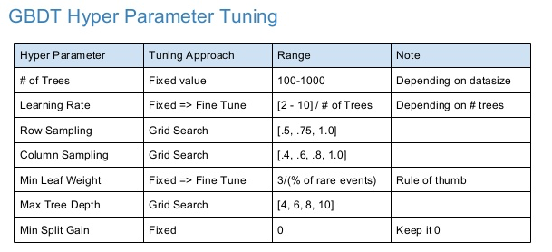

```r
#set up the cross-validated hyper-parameter search
xgb_grid_1 = expand.grid( nrounds = 10,
                         eta = c(0.01, 0.03),
                         max_depth = c(4:6)*2,
                         gamma = c( 0.0, 0.2),
                         subsample = c(0.6, 0.9),
                         colsample_bytree = c( 0.5,0, 0.8),
                         min_child_weight = seq(1,30,10)
                         #,
                         #max_delta_step = seq(1,30,10)
                         )
# xgb_grid_1 = expand.grid(nrounds = 10,
#                          eta = c(0.01, 0.03),
#                          max_depth = c(4),
#                          gamma = c( 0.2),
#                          subsample = c(0.9),
#                          colsample_bytree = c( 0.8),
#                          min_child_weight = seq(1,1,1)
#                          #,
#                          #max_delta_step = seq(1,30,10)
#                          )
dim(xgb_grid_1)
```

```
[1] 216   7
```

```r
xgb_grid_1
```

| nrounds | eta | max_depth | gamma | subsample | colsample_bytree | min_child_weight |
| --- | --- | --- | --- | --- | --- | --- |
| 10 | 0.01 | 8 | 0.0 | 0.6 | 0.5 | 1 |
| 10 | 0.03 | 8 | 0.0 | 0.6 | 0.5 | 1 |
| 10 | 0.01 | 10 | 0.0 | 0.6 | 0.5 | 1 |
| 10 | 0.03 | 10 | 0.0 | 0.6 | 0.5 | 1 |
| 10 | 0.01 | 12 | 0.0 | 0.6 | 0.5 | 1 |
| 10 | 0.03 | 12 | 0.0 | 0.6 | 0.5 | 1 |
| 10 | 0.01 | 8 | 0.2 | 0.6 | 0.5 | 1 |
| 10 | 0.03 | 8 | 0.2 | 0.6 | 0.5 | 1 |
| 10 | 0.01 | 10 | 0.2 | 0.6 | 0.5 | 1 |
| 10 | 0.03 | 10 | 0.2 | 0.6 | 0.5 | 1 |

[output cut: 206 more lines]

```r
fiveStats <- function(...) c(twoClassSummary(...), defaultSummary(...))
fourStats <- function (data, lev = levels(data$obs), model = NULL)
{

  accKapp <- postResample(data[, "pred"], data[, "obs"])
  out <- c(accKapp,
           sensitivity(data[, "pred"], data[, "obs"], lev[1]),
           specificity(data[, "pred"], data[, "obs"], lev[2]))
  names(out)[3:4] <- c("Sens", "Spec")
  out
}
# pack the training control parameters
xgb_trcontrol_1 = trainControl(
  method = "cv",
  number = 5,
  verboseIter = TRUE,
  returnData = FALSE,
  returnResamp = "all",  # save losses across all models
  classProbs = TRUE,     # set to TRUE for AUC to be computed
  summaryFunction = fiveStats,# use custom metrics
  allowParallel = TRUE
)
#xgb_trcontrol_1
```

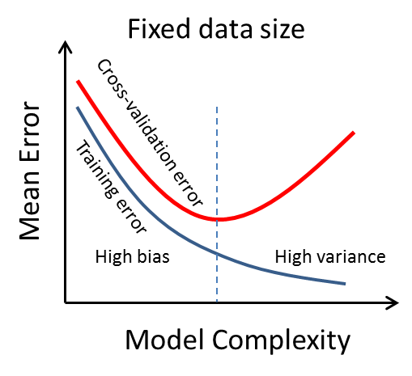

```r
xgb_train_1
```

```
eXtreme Gradient Boosting

No pre-processing
Resampling: Cross-Validated (5 fold)
Summary of sample sizes: 96215, 96214, 96215, 96216, 96216
Resampling results across tuning parameters:

  eta   max_depth  gamma  colsample_bytree  min_child_weight  subsample  ROC
  0.01   8         0.0    0.0                1                0.6        0.4945424
  0.01   8         0.0    0.0                1                0.9        0.4945424
  0.01   8         0.0    0.0               11                0.6        0.4945424
  0.01   8         0.0    0.0               11                0.9        0.4945424
  0.01   8         0.0    0.0               21                0.6        0.4945424
  0.01   8         0.0    0.0               21                0.9        0.4945424
  0.01   8         0.0    0.5                1                0.6        0.8492987
  0.01   8         0.0    0.5                1                0.9        0.8502001
  0.01   8         0.0    0.5               11                0.6        0.8498879
  0.01   8         0.0    0.5               11                0.9        0.8505089
  0.01   8         0.0    0.5               21                0.6        0.8504330
  0.01   8         0.0    0.5               21                0.9        0.8495305
  0.01   8         0.0    0.8                1                0.6        0.8504508
  0.01   8         0.0    0.8                1                0.9        0.8508032
  0.01   8         0.0    0.8               11                0.6        0.8500300
  0.01   8         0.0    0.8               11                0.9        0.8509455
  0.01   8         0.0    0.8               21                0.6        0.8513319
  0.01   8         0.0    0.8               21                0.9        0.8516002
  0.01   8         0.2    0.0                1                0.6        0.4945424
  0.01   8         0.2    0.0                1                0.9        0.4945424
  0.01   8         0.2    0.0               11                0.6        0.4945424
  0.01   8         0.2    0.0               11                0.9        0.4945424
  0.01   8         0.2    0.0               21                0.6        0.4945424
  0.01   8         0.2    0.0               21                0.9        0.4945424
  0.01   8         0.2    0.5                1                0.6        0.8489861
  0.01   8         0.2    0.5                1                0.9        0.8500924
  0.01   8         0.2    0.5               11                0.6        0.8503320
  0.01   8         0.2    0.5               11                0.9        0.8484147
  0.01   8         0.2    0.5               21                0.6        0.8507400
  0.01   8         0.2    0.5               21                0.9        0.8504794
  0.01   8         0.2    0.8                1                0.6        0.8510840
  0.01   8         0.2    0.8                1                0.9        0.8507101
```

[output cut: 140 more lines]

```
  0.9966045  0.08806484  0.9334741  0.14071071
  0.9979001  0.05564484  0.9324265  0.09269539
  0.9980967  0.05133483  0.9323101  0.08583724
  0.9927264  0.14035940  0.9334991  0.20531603
  0.9923422  0.14431013  0.9334159  0.20961144
  0.9935574  0.13401861  0.9338317  0.19940106
  0.9940936  0.13342246  0.9342890  0.20021050
  0.9940221  0.13162669  0.9340977  0.19755870
  0.9937362  0.13605489  0.9341393  0.20306242
 [ reached getOption("max.print") -- omitted 126 rows ]

Tuning parameter 'nrounds' was held constant at a value of 10
Kappa was used to select the optimal model using  the largest value.
The final values used for the model were nrounds = 10, max_depth = 10, eta =
 0.01, gamma = 0.2, colsample_bytree = 0.8, min_child_weight = 1 and subsample = 0.9.
```

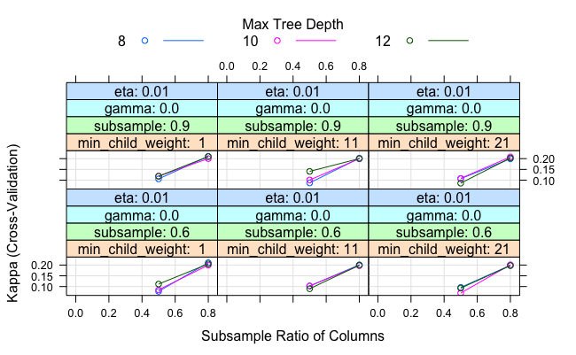

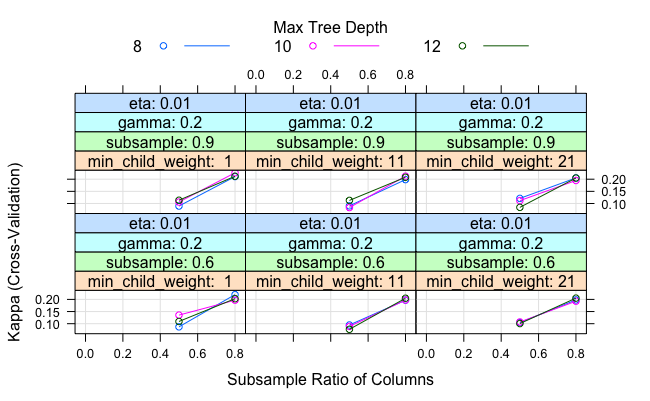

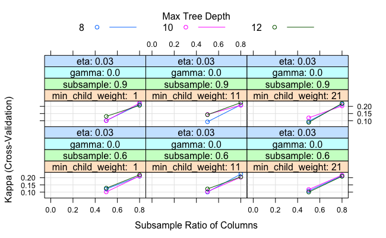

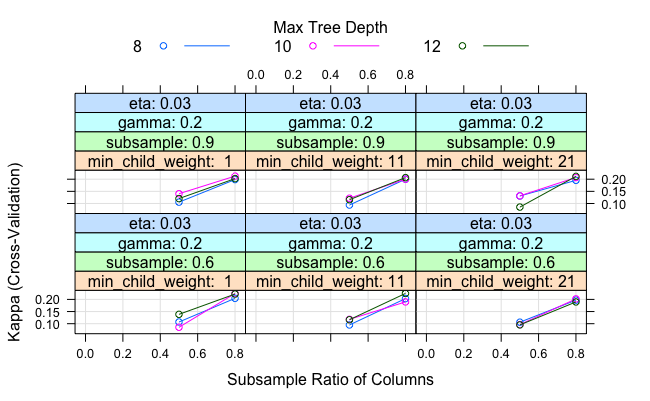

```r
plot(xgb_train_1)
```

```r
fit_results<-as.data.frame(xgb_train_1$results)
fit_results
```

|  | eta | max_depth | gamma | colsample_bytree | min_child_weight | subsample | nrounds | ROC | Sens | Spec | Accuracy | Kappa | ROCSD | SensSD | SpecSD | AccuracySD | KappaSD |
| --- | --- | --- | --- | --- | --- | --- | --- | --- | --- | --- | --- | --- | --- | --- | --- | --- | --- |
| 1 | 0.01 | 8 | 0.0 | 0.0 | 1 | 0.6 | 10 | 0.4945424 | NaN | NaN | NaN | NaN | 0.005360744 | NA | NA | NA | NA |
| 2 | 0.01 | 8 | 0.0 | 0.0 | 1 | 0.9 | 10 | 0.4945424 | NaN | NaN | NaN | NaN | 0.005360744 | NA | NA | NA | NA |
| 3 | 0.01 | 8 | 0.0 | 0.0 | 11 | 0.6 | 10 | 0.4945424 | NaN | NaN | NaN | NaN | 0.005360744 | NA | NA | NA | NA |
| 4 | 0.01 | 8 | 0.0 | 0.0 | 11 | 0.9 | 10 | 0.4945424 | NaN | NaN | NaN | NaN | 0.005360744 | NA | NA | NA | NA |
| 5 | 0.01 | 8 | 0.0 | 0.0 | 21 | 0.6 | 10 | 0.4945424 | NaN | NaN | NaN | NaN | 0.005360744 | NA | NA | NA | NA |
| 6 | 0.01 | 8 | 0.0 | 0.0 | 21 | 0.9 | 10 | 0.4945424 | NaN | NaN | NaN | NaN | 0.005360744 | NA | NA | NA | NA |
| 7 | 0.01 | 8 | 0.0 | 0.5 | 1 | 0.6 | 10 | 0.8492987 | 0.9982486 | 0.04654663 | 0.9321188 | 0.07776271 | 0.005640340 | 0.0011130867 | 0.022438658 | 0.0005440710 | 0.035752065 |
| 8 | 0.01 | 8 | 0.0 | 0.5 | 1 | 0.9 | 10 | 0.8502001 | 0.9976678 | 0.06413652 | 0.9328006 | 0.10576039 | 0.004566973 | 0.0009754308 | 0.018857859 | 0.0006699963 | 0.027870526 |
| 9 | 0.01 | 8 | 0.0 | 0.5 | 11 | 0.6 | 10 | 0.8498879 | 0.9977482 | 0.06210267 | 0.9327341 | 0.10251110 | 0.004558395 | 0.0009364627 | 0.020846378 | 0.0006436869 | 0.032180139 |
| 10 | 0.01 | 8 | 0.0 | 0.5 | 11 | 0.9 | 10 | 0.8505089 | 0.9983290 | 0.05169626 | 0.9325512 | 0.08708671 | 0.005374125 | 0.0006291785 | 0.016781989 | 0.0006221200 | 0.026638083 |

[output cut: 206 more lines]

# Lets Try some random search

```r
# pack the training control parameters
xgb_trcontrol_2 = trainControl(
  method = "cv",
  number = 3,
  verboseIter = TRUE,
  returnData = FALSE,
  returnResamp = "all",  # save losses across all models
  classProbs = TRUE,     # set to TRUE for AUC to be computed
  summaryFunction = fiveStats, # use custom metrics
  search = "random"
)
```

```r
xgb_train_2 = train(
  x = as.matrix(df_train %>%
                  select(-SeriousDlqin2yrs)),
  y = as.factor(df_train$SeriousDlqin2yrs),
  trControl = xgb_trcontrol_2,
  tuneLength = 10,
  method = "xgbTree",
  verbose=T,
  metric="Kappa",
  nthread =4
)
```

```
Fitting nrounds = 448, max_depth = 1, eta = 0.209, gamma = 1.65, colsample_bytree = 0.666, min_child_weight = 4, subsample = 0.713 on full training set
```

```r
fit_results2<-as.data.frame(xgb_train_2$results)
fit_results2
```

|  | eta | max_depth | gamma | colsample_bytree | min_child_weight | subsample | nrounds | ROC | Sens | Spec | Accuracy | Kappa | ROCSD | SensSD | SpecSD | AccuracySD | KappaSD |
| --- | --- | --- | --- | --- | --- | --- | --- | --- | --- | --- | --- | --- | --- | --- | --- | --- | --- |
| 10 | 0.5792474 | 8 | 6.662899 | 0.5072685 | 18 | 0.6523694 | 158 | 0.8349413 | 0.9867932 | 0.1943283 | 0.9317280 | 0.2554176 | 0.0029038636 | 0.0005508994 | 0.007332006 | 0.0008021310 | 0.009836873 |
| 4 | 0.3155347 | 2 | 7.950895 | 0.5102816 | 17 | 0.4053029 | 194 | 0.8537300 | 0.9899475 | 0.1930135 | 0.9345717 | 0.2654426 | 0.0018691352 | 0.0008698789 | 0.012783906 | 0.0004189940 | 0.013324568 |
| 7 | 0.4980873 | 6 | 5.803783 | 0.6288226 | 6 | 0.2670788 | 315 | 0.7923969 | 0.9745514 | 0.2302266 | 0.9228313 | 0.2554035 | 0.0079017981 | 0.0008770091 | 0.011281429 | 0.0003430417 | 0.009952373 |
| 2 | 0.2089269 | 1 | 1.647482 | 0.6655584 | 4 | 0.7130886 | 448 | 0.8513505 | 0.9894828 | 0.1961239 | 0.9343555 | 0.2677029 | 0.0014191501 | 0.0002279890 | 0.007432401 | 0.0004287462 | 0.008869977 |
| 5 | 0.3786241 | 4 | 3.909665 | 0.5636017 | 19 | 0.7051009 | 548 | 0.8431809 | 0.9876510 | 0.1995929 | 0.9328921 | 0.2651526 | 0.0010327278 | 0.0005996175 | 0.004396418 | 0.0007805796 | 0.007113424 |
| 3 | 0.2912895 | 3 | 5.501184 | 0.5292836 | 20 | 0.9949719 | 552 | 0.8546981 | 0.9901083 | 0.1885853 | 0.9344137 | 0.2604974 | 0.0010827358 | 0.0006500298 | 0.006177426 | 0.0001707136 | 0.005424352 |
| 6 | 0.4198487 | 2 | 8.772108 | 0.3830231 | 9 | 0.2938838 | 612 | 0.8498657 | 0.9889020 | 0.1962436 | 0.9338233 | 0.2656149 | 0.0009695811 | 0.0010267380 | 0.007942973 | 0.0004126930 | 0.006175682 |
| 1 | 0.1342560 | 10 | 4.960611 | 0.4595452 | 10 | 0.2914335 | 721 | 0.8368701 | 0.9868021 | 0.1966024 | 0.9318943 | 0.2582590 | 0.0033436086 | 0.0010369523 | 0.009001131 | 0.0010232741 | 0.011036945 |
| 9 | 0.5582607 | 10 | 4.639771 | 0.4055620 | 2 | 0.8434982 | 731 | 0.8051869 | 0.9796626 | 0.2175420 | 0.9267060 | 0.2580986 | 0.0047798146 | 0.0009595678 | 0.008697487 | 0.0009780760 | 0.009982657 |
| 8 | 0.5286341 | 1 | 3.543663 | 0.5593768 | 4 | 0.5665931 | 772 | 0.8475345 | 0.9893130 | 0.1926536 | 0.9339564 | 0.2626639 | 0.0011569251 | 0.0000773845 | 0.007646250 | 0.0005262186 | 0.009646314 |

# Using xgboost package

```r
searchGrid  <- expand.grid(eval_metric = "auc",
                           objective = "binary:logistic",
                           boster = "gbtree",
                           max.depth = c(5,10,15), #Maximum depth of a tree
                           eta = c(0.01,0.5,1),#2/ntrees,  Step size shrinkage used in update to prevents overfitting
                           gamma=0,  # Minimum loss reduction required to make a split
                           lambda=0, # L2 regularization term on weights
                           alpha=0 , # L1 regularization term on weights
                           subsample = c(0.5), #Subsample ratio of the training instance
                           colsample_bytree = 0.6, #Subsample ratio of columns when constructing each tree
                           print.every_n = 25,
                           early_stopping_rounds=10,
                           showsd = TRUE,
                           stratified=TRUE,
                           maximize=TRUE
)

searchGrid
```

```r
best_param = list()
best_seednumber = 1234
best_auc = 0
best_auc_iteration = 0
cv.nfold<-5
cv.nround<-100
best_index<-0

for(i in 1:nrow(searchGrid)){
  param <- list(eval_metric= searchGrid[i,"eval_metric"],
                objective = searchGrid[i,"objective"],
                boster = searchGrid[i,"boster"],
                max.depth =searchGrid[i,"max.depth"],
                eta =searchGrid[i,"eta"],
                gamma=searchGrid[i,"gamma"],
                lambda=searchGrid[i,"lambda"],
                alpha=searchGrid[i,"alpha"],
                subsample = searchGrid[i,"subsample"],
                colsample_bytree = searchGrid[i,"colsample_bytree"],
                print.every_n = searchGrid[i,"print.every_n"],
                early_stopping_rounds=searchGrid[i,"early_stopping_rounds"],
                showsd = searchGrid[i,"showsd"],
                stratified= searchGrid[i,"stratified"],
                maximize= searchGrid[i,"maximize"]
                )

  cat("\n"," ---------- Iteration :", i,"---- \n")

seed.number = sample.int(10000, 1)[[1]]
set.seed(seed.number)

mdcv <- xgb.cv(data = as.matrix(df_train %>% select(-SeriousDlqin2yrs)),
               label = (as.numeric(df_train$SeriousDlqin2yrs)-1),
               params = param,
               nthread=6,
               nfold=cv.nfold,
               nrounds=cv.nround,
               verbose = T,
               maximize=TRUE)

current_auc= max(mdcv$evaluation_log[,test_auc_mean])
max_auc_index = which.max(mdcv$evaluation_log[,test_auc_mean])

  if (current_auc > best_auc)
      {
        best_auc = current_auc
        best_seednumber = seed.number
        best_param = param
        best_auc_iteration=max_auc_index
        best_index<-i
    }
}
```

```r
best_auc
best_seednumber
best_param
best_auc_iteration
best_index

searchGrid[best_index,]
```

```r
best_auc
```

```r
best_seednumber
```

```r
best_param
```

```r
best_auc_iteration
```

```r
best_index
```

```r
searchGrid[best_index,]
```

```r
train.data <- xgb.DMatrix(data=as.matrix(df_train %>% select(-SeriousDlqin2yrs)),
                          label = (as.numeric(df_train$SeriousDlqin2yrs)-1) )

set.seed(best_seednumber)
bst.model <- xgb.train(params = best_param,
                       data = train.data,
                       nrounds = best_auc_iteration,
                       prediction = T)


ypred = predict(bst.model, as.matrix(df_train %>% select(-SeriousDlqin2yrs)))
names <- dimnames(as.matrix(df_train %>% select(-SeriousDlqin2yrs)))[[2]]
importance_matrix<- xgb.importance(names,model = bst.model)

# Nice graph
xgb.plot.importance(importance_matrix[1:10,])
```

[output not shown]